# Statystyka: wykład podstawowy

TP

1/1/2020

# Przedmiot, metody i organizacja badań statystycznych

## Przedmiot statystyki

**Statystyka**: analiza struktury, przedziały ufności i weryfikacja hipotez, analiza współzależności.

**Etapy analizy statystycznej**: – przełóż obserwacje na postać liczbową – wnioskuj (zastosuj odpowiednie statystyki)

**Analiza eksploracyjna** Exploratory research is the stage of the research process that aims at connecting ideas as to unveil the ``why’’s of potential cause/effect relationships. This occurs when researchers get started at understanding what they are actually observing when in the process of building cause/effect models.

**Analiza konfirmacyjna** Confirmatory research (a.k.a. hypothesis testing) is where researchers have a pretty good idea of what’s going on. That is, researcher has a theory (or several theories), and the objective is to find out if the theory is supported by the facts.

**Opis statystyczny** – liczbowe przedstawienie badanych zbiorowości lub zjawisk w postaci opisu: – tabelarycznego; – graficznego; – parametrycznego

**Opis statystyczny** może dotyczyć: – struktury zbiorowości; – współzależności; – zmian zjawisk w czasie.

**Badanie statystyczne** to zespół czynności zmierzających do uzyskania (za pomocą metod statystycznych) informacji charakteryzujących badaną zbiorowość lub zjawisko. Najważniejsze kryteria klasyfikacji badań: – zakres obserwacji badanych jednostek (pełne, częściowe); – częstotliwość: (ciągłe, okresowe, doraźne); – zasięg przestrzenny (międzynarodowe, krajowe, regionalne, środowiskowe, monograficzne); – dziedzina badań (demograficzne, społeczne, ekonomiczne, rolnicze, jakości środowiska naturalnego itp.

**Populacja, zbiorowość statystyczna**: zbiór obiektów (osób, przedmiotów, zdarzeń) logicznie ze sobą powiązanych (ale nie identycznych), poddany badaniu statystycznemu.

**Jednostka statystyczna**: jednostki statystyczne w danej populacji różnią się od innych jednostek spoza danej populacji poprzez swoje własności wspólne (cechy stałe), jednocześnie różnią się między sobą cechami (cechy zmienne), które są przedmiotem zainteresowania badacza.

**Cechy statystyczne** – właściwości jednostek statystycznych Cechy stałe – jednakowe dla wszystkich jednostek badania: rzeczowa (co? kto? jest badane/y) przestrzenna (gdzie?) czasowa (kiedy?)

**Cechy zmienne** – właściwości różnicujące jednostki jednostki z badanej populacji, tj. takie które mogą posiadać więcej niż 1 wariant (jeżeli posiadają jeden mamy do czynienia z przypadkiem trywialnym). Cechy zmienne dzielimy na: – jakościowe (płeć, rok studiów) – ilościowe (wiek)

**Pomiar** – przyporządkowanie wariantom cechy zmiennej ustalonych liczb lub symboli. W naukach przyrodniczych (fizyka, chemia) pomiaru dokonuje przy zastosowaniu precyzyjnych/jednoznacznie określonych definicji **miar**. W naukach społecznych jest niestety inaczej: wiele definicji jest nieprecyzyjnych (turysta), a wiele miar przybliżonych. Przy czym brak precyzji pomiaru nie wynika z błędu pomiaru (źle przyłożona linijka), ale jest cechą użytej **skali pomiarowej** (nieprecyzyjna linijka).

**Rodzaje skal pomiarowych** – **nominalna** (nominal scale), klasyfikuje: płeć; – **porządkowa** (ordinal scale), klasyfikuje i porządkuje: zdolność kredytowa firmy, stadia choroby, – **przedziałowa** (interval scale), posiada jeszcze stałą jednostkę miary (ów przedział) oraz umowne zero (temperatura) – **ilorazowa** (rational scale), posiada to co przedziałowa plus naturalne zero (wiek, wzrost, obrót, temperatura).

Skala Kelvina temperatury jest ilorazowa, skala Celsiusza jest przedziałowa. Zero w skali Kelvina to zero bezwzględne, 200K jest 2 razy mniejsze niż 400K podczas gdy 200C nie jest dwa razy mniejsze niż 400C. Na skali przedziałowej **nie można** w bezpieczny sposób dokonywać dzielenia. Na liczbach w skali porządkowej nie można dokonywać nawet dodawania. **Wszystkie operacje arytmetyczne są bezpieczne tylko dla skali ilorazowej.**

**Cecha statystyczna mierzalna (ilościowa)** – określana jest za pomocą liczb np. oceny, płace. Cechy mierzalne dzielą się na skokowe i ciągłe. Skokowe są to cechy, które przyjmują skończoną liczbę wartości, zwykle są to liczby całkowite; Ciągłe są to cechy, które przyjmują dowolne wartości liczbowe z pewnego przedziału liczbowego np. dochody, długość ziarna fasoli.

**Data wrangling**, sometimes referred to as **data munging**, is the process of transforming and mapping data from one raw data form into another format with the intent of making it more appropriate and valuable for a variety of downstream purposes such as analytics.

**Data science** also known as data-driven science, is an interdisciplinary field of scientific methods, processes, algorithms and systems to extract knowledge or insights from data in various forms, either structured or unstructured.

**Statistics** Programs -> Data -> Knowledge

**Data Science** Data -> Programs -> Knowledge

Pojęcia stosowane w statystyce publicznej https://stat.gov.pl/metainformacje/slownik-pojec/pojecia-stosowane-w-statystyce-publicznej/lista.html

## Rodzaje badań statystycznych

**Pełne** (spis, rejestracja), **częściowe** (reprezentacyjne), **szacunki interpolacyjne i ekstrapolacyjne** (ustalenie wartości na podstawie znanych wartości podobnych/poprzednich/sąsiednich; wbrew pozorom często stosowana metoda).

**Ciągłe** (ewidencja urodzeń), **okresowe** (spisy rolne, spis powszechny), **doraźne** (sondaż poparcia w wyborach prezydenckich)

**Spis** gromadzenie danych na potrzeby badania; **Rejestracja** gromadzenie danych przy okazji wykonywania innych działań (ewidencja ludności, działanie wymiaru sprawiedliwości, gromadzenie danych pogodowych itp…)

**Reprezentacyjne** badanie oparte na **próbie** pobrane ze zbiorowości w taki sposób, że wyniki uzyskane dla tej próby można uogólnić na całą populację (wymaga to odpowiedniego sposobu wybrania jednostek do próby; nie każda próba jest **reprezentacyjna**)

## Organizacja badań statystycznych

Etapy wstępne badania statystycznego:

- ustalenie **celu i metody** (pełne częściowe);
- określenie **zbiorowości** i **jednostki badania**;
- określenie **cech/wartości cech** podlegających gromadzeniu (*definiowanie/klasyfikacja**) oraz sposobu pomiaru;
- zdefiniowanie **jednostki sprawozdawczej** (od kogo pozyskamy dane).

**Klasyfikacja** to ustalenie (wyodrębnienie) wariantów cechy. Cechy/wartości cech nie mogą być wymyślane ad hoc ale (w imię porównywalności) powinny być definiowane z użyciem powszechnie stosowanych słowników/taksonomii/klasyfikacji (TERYT, PESEL, EKD)

Kto to jest turysta? Co to jest hotel? Co to jest las?

**Pomiar** (obserwacja). **Materiał pierwotny** (dane zgromadzone specjalnie dla celów badania), **materiał wtórny** (dane zgromadzone z innych powodów ale przydatne do badania statystycznego; dane rejestrowane). Wg Sobczaka: większą wartość mają materiały pierwotne, ponieważ są aktualne, gromadzone z określoną dokładością i nie są obciążone zbytecznymi informacjami. Powyższe można uznać za mocno nieaktualne. Współcześnie dane z rejestrów są coraz zarówno lepsze jakościowo jak i dominują ilościowo (Facebook/Google, którego wszyscy się boją:-)).

## Opracowanie danych

**Grupowanie** – podział zbiorowości na jednorodne lub względnie jednorodne podgrupy z punktu widzenia wyróżnionej cechy (cech): – typologiczne (cechy jakościowe); – wariancyjne (cechy ilościowe).

Zasady logiki formalnej: grupowanie musi być wyczerpujące – każda jednostka zbiorowości musi być sklasyfikowana i włączona do odpowiedniej podgrupy; – grupowanie powinno być rozłączne – wyodrębnione podgrupy muszą się wzajemnie wykluczać; – grupowanie powinno być efektywne – wyróżnione podgrupy powinny być na tyle jednorodne jakościowo, by mogły stanowić podstawę twierdzeń uogólniających

**Szereg statystyczny** to zbiorowość statystyczna (populacja) uporządkowana (**szereg szczegółowy**) lub uporządkowana i pogrupowana (**Szereg rozdzielczy**) według określonych kryteriów (wariantów cechy).

Wg GUS (cf https://stat.gov.pl/metainformacje/slownik-pojec/pojecia-stosowane-w-statystyce-publicznej/2793,pojecie.html) Ciąg wielkości statystycznych, otrzymanych w wyniku obserwacji statystycznej lub pomiaru, uporządkowanych według określonych kryteriów (cech) – podstawowa forma prezentacji danych statystycznych.

Wyróżnia się następujące szeregi statystyczne: szereg szczegółowy, szereg rozdzielczy (**strukturalny**), szereg przestrzenny (geograficzny) i szereg czasowy (**dynamiczny**).

Szereg strukturalny – opis zbiorowości statystycznej w określonym momencie czasu (wiek nowożeńców w powiecie kwidzyńskim w 2019 roku); szereg czasowy – opis zbiorowości w pewnych okresach (**strumieni**) lub momentach (**stan**) czasu.

Liczba urodzeń w powiecie kwidzyńskim w latach 2000–2019 to szereg czasowy okresów (strumieni); w szczególności można dodać liczbę urodzeń w poszczególnych latach otrzymując łączną liczbę urodzonych w tym okresie.

Liczba zarejestrowanych pojazdów w powiecie kwidzyńskim w latach 2000–2019 to szereg momentów (stan); nie można sumować liczby zarejestrowanych samochodów, bo taka suma nie ma merytorycznie sensu. Można podać średnią–przeciętny stan zarejestrowanych samochodów w latach 2000–2019.

**Szereg przestrzenny** (geograficzny) – przedstawia rozmieszczenie wielkości statystycznych według podziału administracyjnego (gmina, powiat, województwo, itd).

Szereg strukturalny: rozkład wartości cechy; szereg czasowy: zmiana wartości w czasie; szereg przestrzenny rozkład cechy na powierzchni Ziemi.

Szereg rozdzielczy przestawia się zwykle w postaci **tablicy statystycznej**.

Szereg szczegółowy (przykład):

```
Gospodarstwa domowe wg liczby samochodów

0 0 0 0 0 0 0 ... 1 1 1 1 1 1 1 1 ...
```

Szereg rozdzielczy dla cechy niemierzalnej:

```
Tablica 1. Struktura próby mieszkańców wg wykształcenia

Wykształcenie liczba osób odsetek w %
-------------------------------------
podstawowe i gimnazjalne 130  13,0
zawodowe                 272  27,2
średnie                  444  44,5
wyższe                   153  15,3
Ogółem                   999 100,0
```

Szereg rozdzielczy punktowy:

```
Gospodarstwa domowe wg liczby samochodów

Liczba samochodów    Liczba gospodarstw
---------------------------------------
0                      230
1                      280
2                       70
3 i więcej               5
Razem                  585
```

Szereg rozdzielczy przedziałowy:

```
Studenci według czasu wolnego

Czas wolny w min.     Liczba osób
--------------------------------
30,1 - 60                      3
60,1 - 90                      4
90,1 - 120                     6
120,1 - 150                    5
150,1 - 180                    3
180,1 - 210                    1
Razem                         22
```

**Budowa tablic statystycznych**: 1. Część liczbowa (kolumny i wiersze); 2. Część opisowa: – tytuł tablicy; nazwy wierszy; nazwy kolumn; – źródło danych; – ewentualne uwagi odnoszące się do danych liczb.

## Wizualizacja danych i wykresy

**Wykresy statystyczne** są graficzną formą prezentacji materiału statystycznego, są mniej precyzyjne i szczegółowe niż tablice, natomiast bardziej sugestywne.

Rodzaje wykresów (podział ze względu na zastosowanie):

**Jedna cecha**

**szeregi strukturalne**: punktowe, słupkowe, histogram, pudełkowe, kołowe; **szeregi czasowe**: liniowe, słupkowe, punktowe; **szeregi przestrzenne**: kartogramy.

**Dwie cechy**

wykres rozrzutu (scatter-plot), liniowy

# Analiza struktury

## Pojęcia wstępne

Analiza struktury – opisane zbiorowości ze względu na obserwowane w badaniu cechy zmienne.

Podstawę do oceny struktury zbiorowości stanowią dane w postaci **szeregu szczegółowego**, bądź też pogrupowane (**szereg rozdzielczy**)

Analizę prowadzić można na podstawie wykresów, szeregów rozdzielczych oraz (najczęściej) za pomocą odpowiednio obliczonych charakterystyk, zwanych parametrami (dla populacji) lub statystykami (dla próby).

**Rozkład cechy** – przyporządkowanie liczby wystąpień (liczebności, częstości lub prawdopodobieństwa) odpowiednim wartościom cechy zmiennej.

Analiza struktury obejmuje: **określenie tendencji centralnej** (tzw. **miary położenia** / wartość przeciętna, mediana, dominanta); **zróżnicowanie wartości** (rozproszenie); **asymetrię** (rozłożenie wartości wokół średniej); **koncentrację** (podział wartości cechy pomiędzy jednostki)

## Wykresy

Celem jest pokazanie rozkładu wartości cechy w populacji: jakie wartości występują często a jakie rzadko, jak bardzo wartości różnią się między sobą. Jak różnią się rozkłady dla różnych ale logicznie powiązanych populacji (np rozkład czegoś-tam w kraju A i B albo w roku X, Y i Z). Do tego celu stosuje się: **histogram** (albo wykres słupkowy dla skal nominalnych), **wykres punktowy**, **wykres pudełkowy** oraz **kołowy**. Omówimy je na przykładach

**Przykład 1: Dzietność kobiet na świecie**

Współczynnik dzietności – przeciętna liczba urodzonych dzieci przypadających na jedną kobietę w wieku rozrodczym (15–49 lat). Przyjmuje się, iż FR między 2,10–2,15 zapewnia zastępowalność pokoleń.

Plik `fertility_rate_2003_2018.csv` (źródło: https://ourworldindata.org/grapher/fertility-rate-complete-gapminder) zawiera wartości współczynnika w roku 2003 oraz 2018 (czyli po 15 latach) dla 202 krajów.

Do oceny rozkładu wartości zmiennej służy **histogram** (por https://pl.wikipedia.org/wiki/Histogram). Jeżeli umieścimy obok siebie dwa (lub więcej) histogramy, możemy w ten sposób porównać (wizualnie) dwa rozkłady:

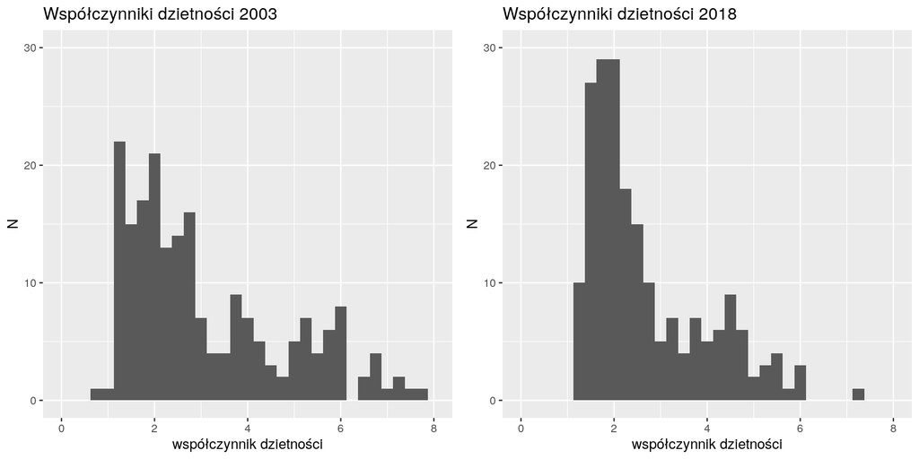

Kształt histogramu zależy od wyboru rozpiętości przedziału; im przedział węższy tym więcej słupków (ale ich wysokość będzie mniejsza). Poniżej przedstawiono ten sam rozkład dla rozpiętości przedziału równej odpowiednio 0,1, 0,25 oraz 0,5:

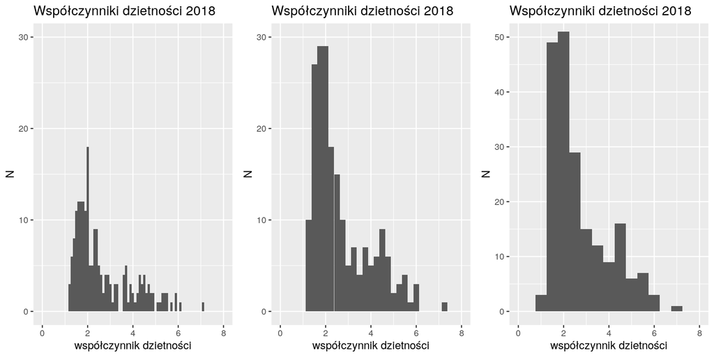

Dlatego jeżeli porównujemy różne rozkłady za pomocą umieszczonych obok siebie histogramów to powinny one mieć: tę samą rozpiętość przedziałów, te same skale na obu osiach.

Istnieją wzory na optymalną liczbę przedziałów ale nalepszą metodą jest metoda prób i błędów.

Czasami jeżeli liczebność populacji nie jest za duża można spróbować przedstawić rozkład cechy na wykresie punktowym:

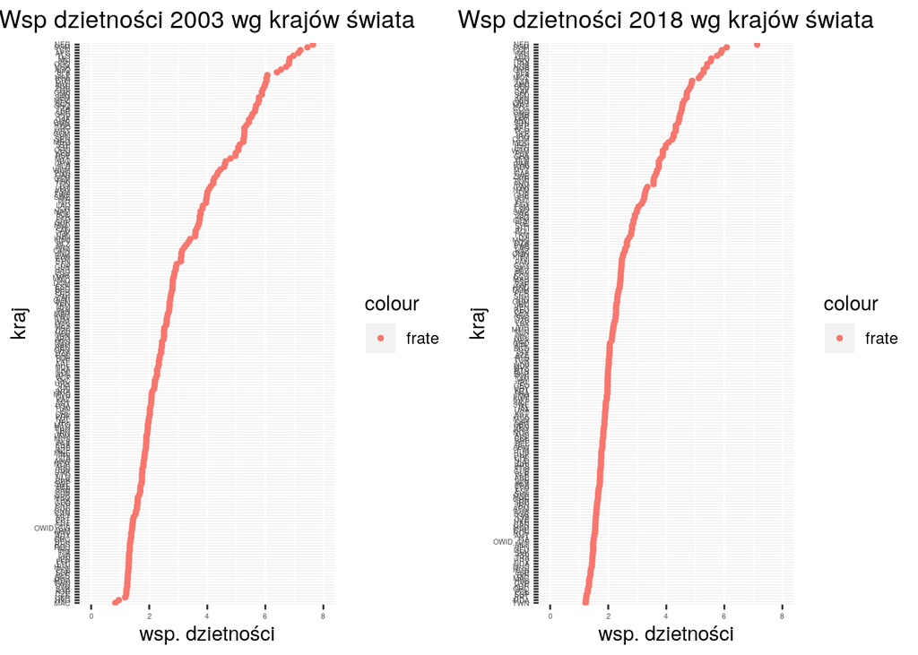

**Porównanie wielu rozkładów**

Jeżeli używamy histogramu to w zasadzie jedyną opcją jest wykreślenie każdego histogramu oddzielnie a następnie umieszczenie ich obok siebie. Wyjątkowo można spróbować wykreślić dwa na jednym wykresie (jeżeli program, którym się posługujemy umożliwia rysowanie kolorem przeźroczystym):

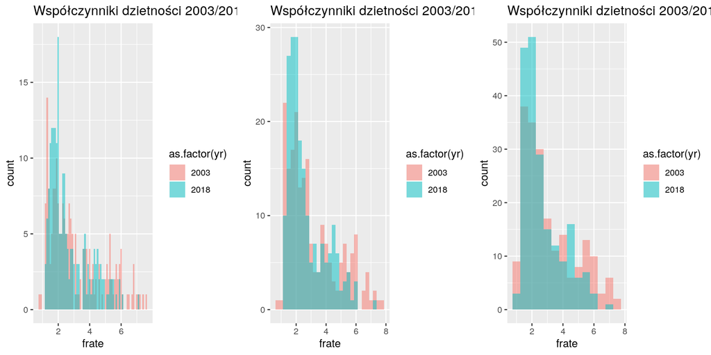

Łącznie na jednym wykresie (wykres punktowy):

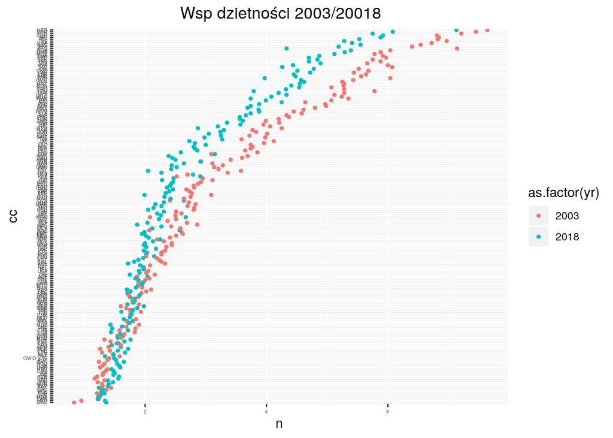

**Przykład 2: Wykresy kołowe (Pie charts), wykresy punktowe (dot plots), histogram**

Dane pochodzą z bazy danych Eurostatu są dostępne pod adresem https://appsso.eurostat.ec.europa.eu/nui/show.do?dataset=tour_occ_nim&lang=en

Nights spent at tourist accommodation establishments by non residents (id tabeli: `tour_occ_ninat`) czyli po polsku *Noclegi udzielone w turystycznych obiektach noclegowych* (https://ec.europa.eu/eurostat/web/products-datasets/-/tin00175; https://stat.gov.pl/metainformacje/slownik-pojec/pojecia-stosowane-w-statystyce-publicznej/1233,pojecie.html; https://stat.gov.pl/en/metainformations/glossary/terms-used-in-official-statistics/1233,term.html) Poniższy rysunek przedstawia typową tabelę (wielowymarową) z danymi dotyczącymi wykorzystania miejsc noclegowych w krajach UE.

Nagłówek tabeli: **TIME**, **GEO**, **Unit of measure**, **Classification of economic activities**, **Country of residencie** definiuje cechy stałe zbiorowści statystycznej. Dla każdej cechy zwykle możliwy jest wybór z kilku dostępnych wariantów. Tabela na rysunku przedstawia dane roczne, dla krajów UE, dotyczące liczby noclegów w *hotels, holidays and other short-stay accomodations, camping grounds, recreational vehicle parks and trailes parks* (Hotele, Obiekty noclegowe turystyczne i miejsca krótkotrwałego zakwaterowania, Pola kempingowe, włączając pola dla pojazdów kempingowych i pola namiotowe; https://ec.europa.eu/eurostat/ramon/nomenclatures/index.cfm). Skrót NACE oznacza klasyfikację działalności gospodarczej, która służy do określenia jakie miejsca noclegowe są uważane za **turystyczne** (bo to nie jest oczywiste).

[figure not shown]

Liczbę noclegów dla 10 najczęściej odwiedzanych przez turystów krajów (oraz dla reszty oznaczonej jako Rest28) przestawiono na **wykresie kołowym** (https://pl.wikipedia.org/wiki/Diagram_ko%C5%82owy). Wielkość każdego wycinka koła (pole tego wycinka albo, kąt) jest proporcjonalna do liczby noclegów w danym kraju. Stąd wykres kołowy wizualizuje **udział** (popularnie zwany procentem) każdego wycinka w całości. Możemy dodać etykiety zawierające albo ów udział (prawy wariant na przykładzie poniżej); albo oryginalne liczby.

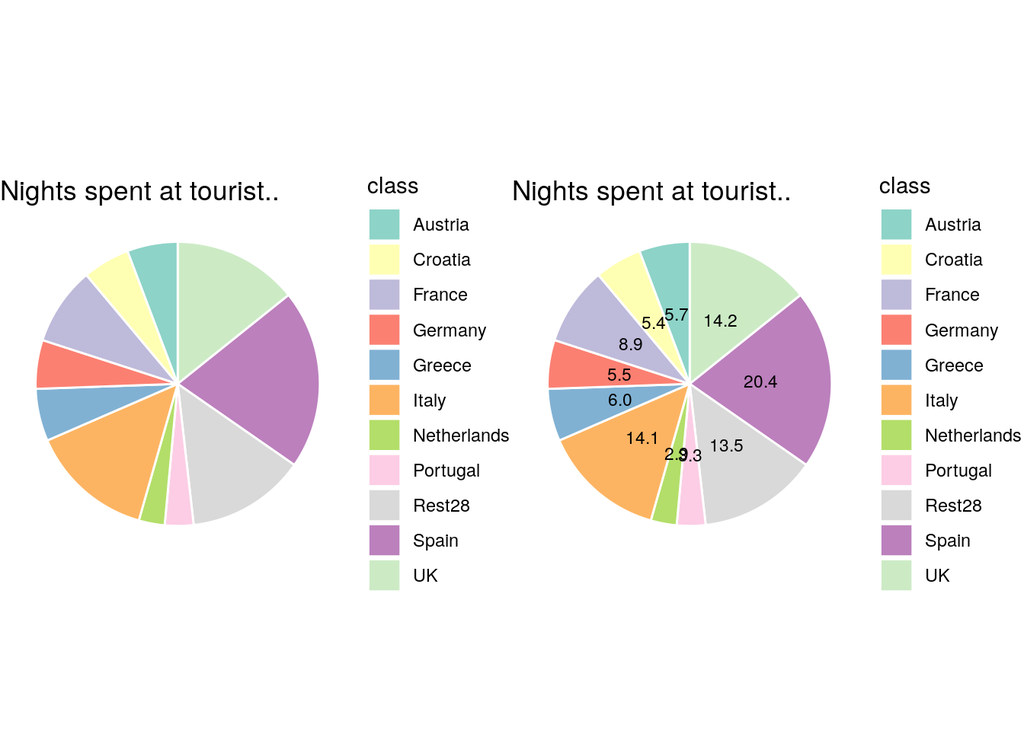

Wykres pokazuje dobitnie wszystkie wady wykresu kołowego: niemożliwe jest określnie różnic pomiędzy wycinkami, chybna że różnice te są ogromne. Np niemożliwe jest ustalenie czy jak bardzo różni się udział w UK i Francji. Albo czy liczba noclewgów w Austrii jest mniejsza/większa/równa niż w Niemczech, itd… Jeżeli dodamy liczby to sprawa się wyjaśni (prawy wariant) tylko po co wtedy rysunek?

Znacznie bardziej efektywne są wykresy punktowe (lewy) lub słupkowe (prawy):

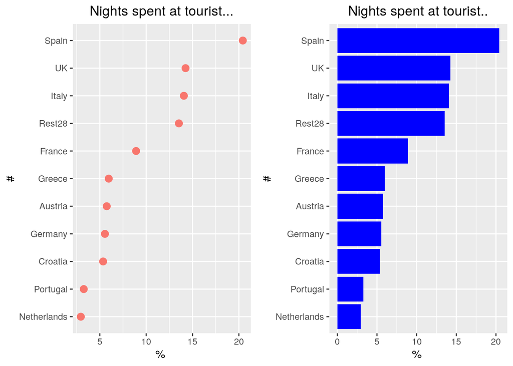

Dużo lepiej widać różnice pomiędzy krajami. Niepotrzebna jest legenda. Nazwy krajów są na osi OY, liczba noclegów na osi OX. Na wykresie kołowym albo w wycinku mieściła się nazwa kraju albo procent nie było miejsca dla obu, stąd potrzebna była legenda (utrudniająca interpretację)

Wniosek: każdy wykres kołowy można i TRZEBA zamienić na słupkowy. Wykresów kołych nie należy stosować bo są znacznie gorszym sposobem wizualizacji informacji niż słupkowe.

**Przykład 3: Wykres pudełkowy**

Uwaga: poniższy opis **wykresu pudełkowego** zawiera pojęcia jeszcze nie wyjaśnione (kwartyle, mediana, rozproszenie i IQR), które opisano dokładanie dalej, w punktach miary położenia/miary zmienności.

Konstrukcja pudełka na wykresie: górny/dolny bok równy kwartylom, a linia pozioma w środku pudełka równa medianie; linie pionowe (zwane wąsami) mają długość równą Q1 minus 1,5 IQR oraz Q3 plus IQR (Q1, Q3 to kwartyle, IQR to odstęp między kwartlowy; co to jest kwartyl, mediana i odstęp międzykwartylowy jest wyjaśnione poniżej); Linia pozioma w połowie pudełka określa przeciętny poziom zjawiska; wysokość pudełka/wąsów określa zmienność (im większe wąsy/wysokość tym większa zmienność). Obserwacje nietypowe (czyli takie których wartość jest albo mniejsza od $Q1 - 1,5IQR$ albo większa od $Q3 + 1,5IQR$)są zaznaczana indywidualnie jako kropki nad/pod wąsami.

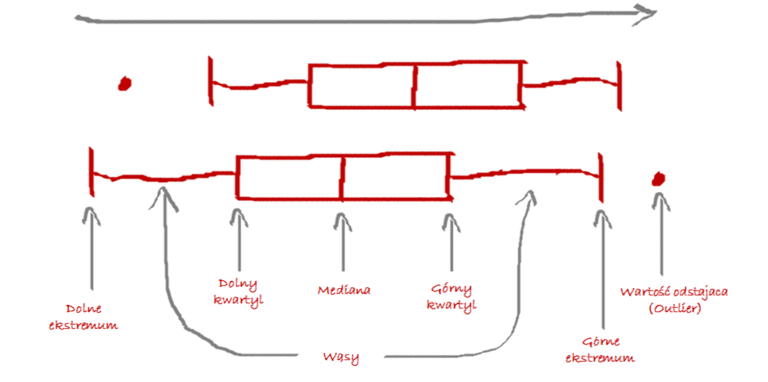

Ze strony komiteu Noblowskiego pobrano listę Laureatów Nagrody Nobla Wiek laureatów nagrody Nobla w momencie przyznania nagrody (ponad 900 laureatów; plik `nobel_laureates3.csv`):

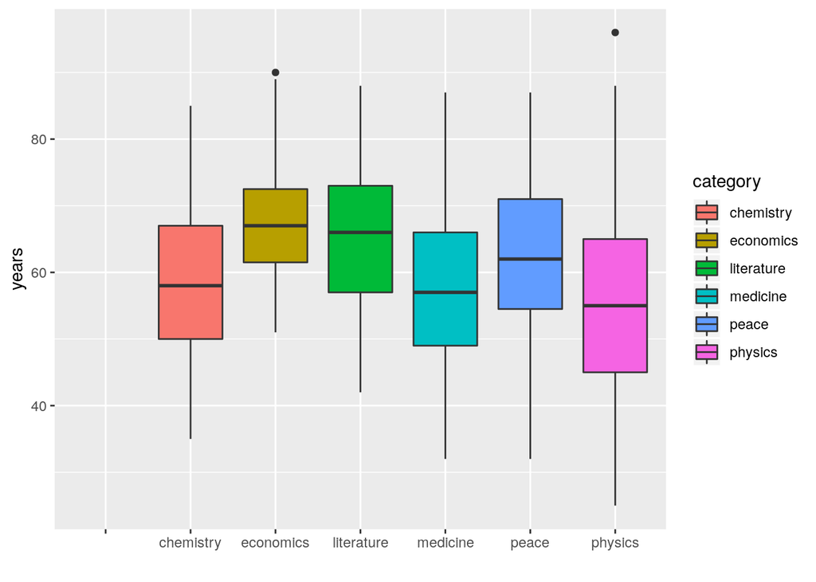

Najstarsi przeciętnie: ekonomia; najmłodsi przeciętnie: fizyka. Najmniejsze zróżnicowanie: ekonomia; największe zróżnicowanie: fizyka. Nie ma szans na nobla (koniec dolnego wąsa) przed pięćdziesiątką w ekonomii, przed 40-tką w literaturze, przed trzydziestką w chemii, medycynie i nagrodzie pokojowej.

Wykres niezwykle użyteczny do porównywania różnic w rozkładach wartości cechy.

**Przykład 4: Zaufanie do Politykow**

CBOS realizuje co najmniej 12 razy w roku sondaż “Aktualne problemy i wydarzenia”, na reprezentatywnej ok. 1000-osobowej próbie dorosłych mieszkańców Polski. (cf https://www.cbos.pl/PL/trendy/trendy.php?)

Częścią tych badań jest badanie zaufania do Polityków. Które to zaufanie jest mierzone w taki sposób, że respondenci odpowiadają na jedno pytanie, które brzmi: *Ludzie aktywni publicznie – swoim zachowaniem, tym, co mówią, do czego dążą – budzą mniejsze lub większe zaufanie. Przedstawimy teraz Panu(i) listę osób aktywnych w życiu politycznym naszego kraju. O każdej z nich proszę powiedzieć, w jakim stopniu budzi ona Pana(i) zaufanie. Odpowiadając, proszę posłużyć się skalą, na której –5 oznacza, że osoba ta budzi w Panu(i) głęboką nieufność, 0 – że jest ona Panu(i) obojętna, a +5 oznacza, że ma Pan(i) do tej osoby pełne zaufanie. Oczywiście może się Pan(i) posługiwać innymi ocenami tej skali. Jeżeli kogoś Pan(i) nie zna, proszę powiedzieć*

Odsetki badanych wyrażających zaufanie – wskazania punktów od +1 do +5, nieufność – wskazania punktów od –1 do –5, obojętność – 0

W zestawieniu CBOS pomija odpowiedzi „trudno powiedzieć” i odmowy odpowiedzi.

Analiza CBOS (przykład raportu jest w pliku `zaufanie_do_politykow_CBOS_2019.pdf`) posługuje się skumulowanym wykresem słupkowym (*stacked barchart*):

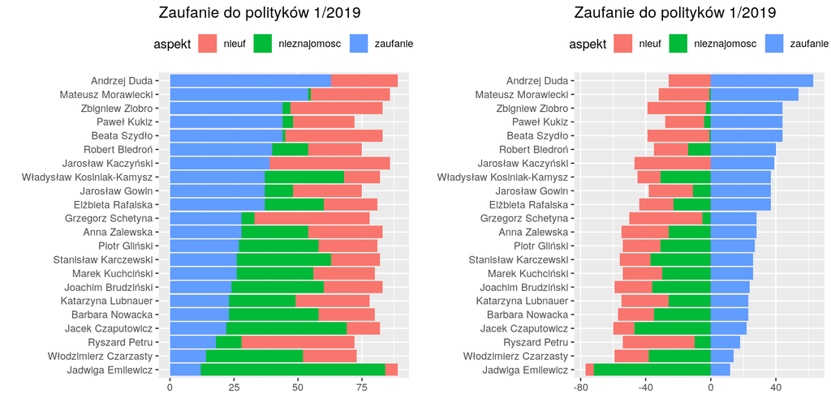

Skumulowany wykres słupkowy jest w zasadzie jest wykresem kołowym, tyle że zamiast kółek są prostokąty (cf https://eagereyes.org/techniques/stacked-bars-are-the-worst). Można łatwo porównywać łączną wartość albo wartość przedstawioną za pomocą pierwszego słupka (bo mają wspólną linię dla wartości zero, *common baseline*). Pozostałe słupki nie są oparte o wspólną linię zerowej wartości i w związku z tym porównanie ich wartości jest trudne. W przykładzie każdy słupek ma 3 kategorie a już jest trudno wskazać czy nieufność do Pawła Kukiza jest większa czy mniejsza od nieufności do Roberta Biedronia. Gorzej wykres sugeruje, że nieufność do Biedronia jest większa niż do Kukiza, podczas gdy w rzeczywistości jest odwrotnie. Podobnie trudno jest określić dla konkretnego polityka czy zaufanie jest większe od nieufności albo o ile jest większe (lub mniejsze)..

Można trochę poprawić wykres jeżeli wartości podzielimy na ujemne/dodatnie (wykres po prawej). Można ale po co? Najlepiej po prostu wykreślić oddzielne wykresy słupkowe dla każdej kategorii czyli wykreślić słupki z każdej kategorii oddzielniem na wspólnej linii zera:

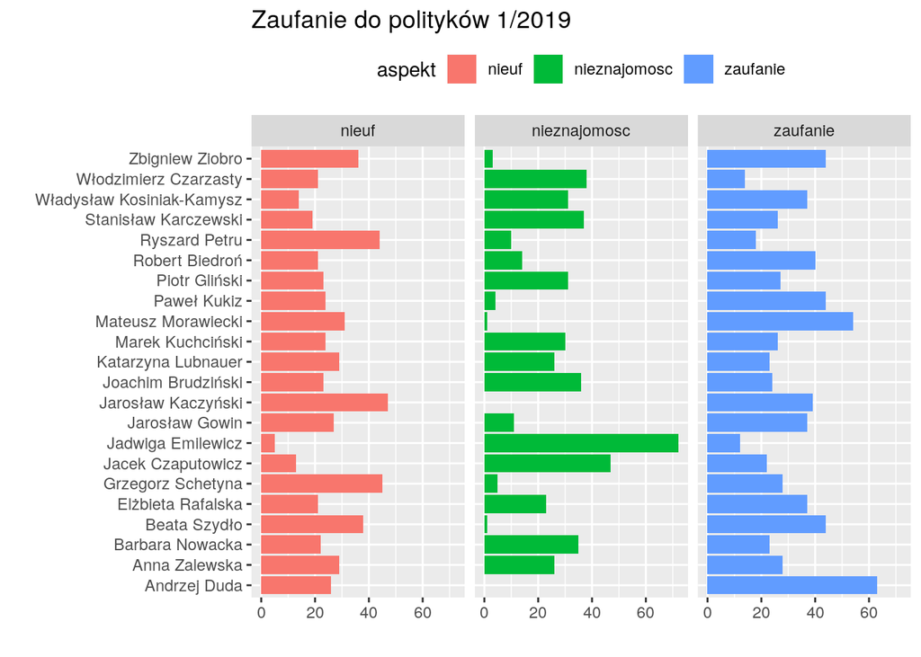

Wykres kołowy kolejny raz jest najmniej przydatny. Niemożliwe albo bardzo trudne jest zorientowanie się w różnicach odsetka zaufania/nieufności/nieznajmości dla poszczególnych kandydatów:

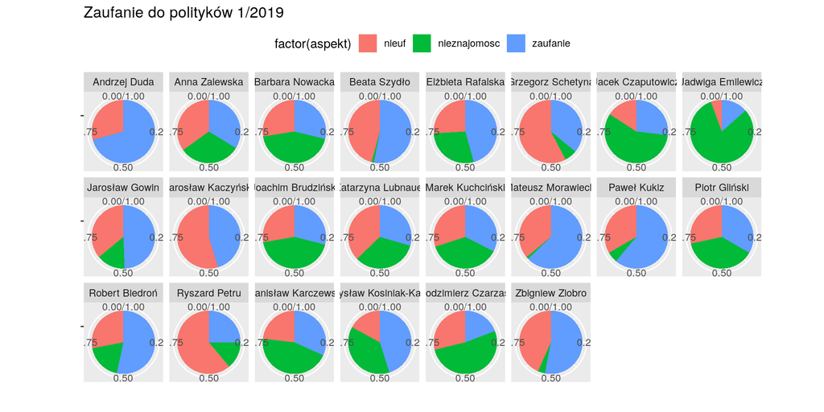

Można spróbować połączyć wykres punktowy z wykresem słupkowym:

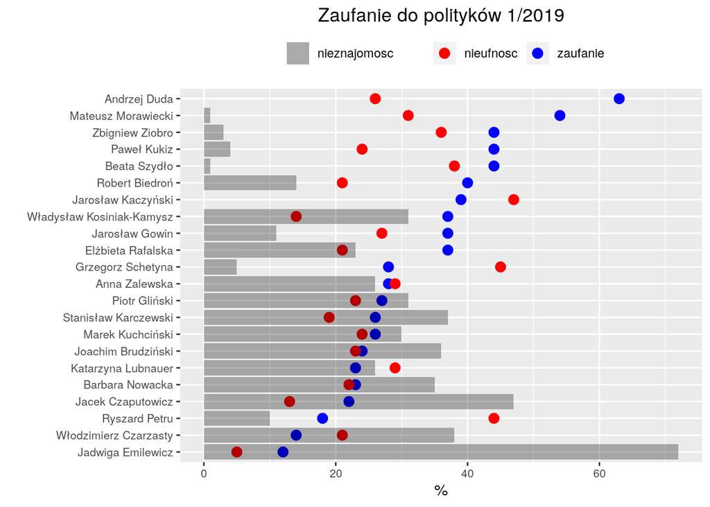

Patrząc na słupki można ocenić nieznajomość; patrząc na kropki zaufanie/nieufność. W porówaniu do skumulowanego wykresu słupkowego zarówno łatwe jest porównanie poziomów każdego czynnika dla wszystkich ocenianych polityków, jak i porównanie dla konkretnego polityka (czy zaufanie jest większe od nieufności albo o ile jest większe/mniejsze). Ale uwaga jeżeli liczba wymiarów będzie większa niż trzy wykres straci na przejrzystości zamieniając się w chmurę różnokolorowych kropek.

## Analiza parametryczna

### Miary położenia

Miary przeciętne charakteryzują średni lub typowy poziom wartości cechy. Są to więc takie wartości, wokół których skupiają się wszystkie pozostałe wartości analizowanej cechy.

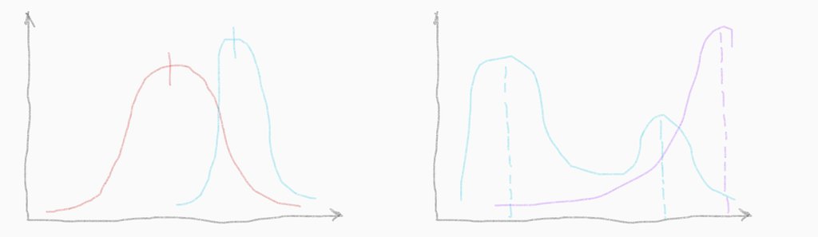

Na rysunku po lewej mamy dwa rozkłady różniące się poziomem przeciętnym (czerwony ma przeciętnie mniejsze wartości niż turkusowy). Są to rozkłady jednomodalne, tj. wartości skupiają się wokół jednej wartości. Dla takich rozkładów ma sens obliczanie średnich.

Na rysunku po prawej mamy rozkłady nietypowe: wielomodalne (turkusowy) lub niesymetryczne (wartości skupiają się nie centralnie ale po prawej/lewej od środka przedziału zmienności).

W świecie rzeczywistym zdecydowana większość rozkładów jest jednomodalna.

Klasyczne (**średnia arytmetyczna**) i pozycyjne (**mediana**, **dominanta**, kwartyle, kwantyle, decyle).

Średnia artmetyczna (*Mean*, *Arithmetic mean*). Oblicznie średniej dla szeregu prostego (suma wartości podzielona przez liczbę składników sumy):
$$\bar x = \frac{\sum_{i=1}^N x_i} {N}$$

**Mediana** (*Median*, kwartyl drugi) dzieli zbiorowość na dwie równe części; połowa jednostek ma wartości cechy mniejsze lub równe medianie, a połowa wartości cechy równe lub większe od Me. Stąd też mediana bywa nazywana wartością środkową.

**Właśności mediany** – odporna na wartości nietypowe (w przeciwieństwie do średniej)

**Przykład: współczynnik dzietności na świecie w roku 2018**

Średnia wartość współczynnika 2.6778607; mediana – 2.2. Interpretacja średniej: wartość współczynnika dzietności wyniosła 2.6778607 dziecka. Uwaga: średnia dzietność na świecie **nie wynosi** 2.6778607 (bo kraje różnią się liczbą ludności). Interpretacja mediany: dzietność kobiet w połowie krajów na świecie wynosiło 2.2 i mniej. Uwaga: dzietność połowy kobiet na świecie wyniosła 2.2 i mniej jest niepoprawną interpretacją (różne wielkości krajów.)

**Generalna uwaga**: interpretacja średniej-średnich często jest nieoczywista i należy uważać. (a współczynnik dzietości jest średnią: średnia liczba dzieci urodzonych przez kobietę w wieku rozrodczym. Jeżeli liczymy średnią dla 202 krajów, to mamy *średnią-średnich*). Inny przykład: odsetek ludności w wieku poprodukcyjnym wg powiatów (średnia z czegoś takiego nie da nam odsetka ludności w wieku poprodukcyjnym w Polsce, bo powiaty różnią się liczbą ludności.)

**Dominanta** (*Mode*, Moda, wartość modalna, wartość najczęstsza) jest to wartość cechy statystycznej, która w szeregu empirycznym występuje najczęściej. W szeregach prostych i rozdzielczych jest to wartość cechy, której odpowiada największa liczebność (częstość).

**Kwartyle** (Q, *quartile*, $Q_1$, $Q_3$) – wartości cechy dla jednostek dzielących populację na cztery równe części. Kwartyl pierwszy dzieli populację w proporcji 25/75%, kwartyl drugi w proporcji 50/50%, a kwartyl trzeci w proporcji 75/25%. **kwantyle** (D, wartości dziesiętne), podobnie jak kwartyle, tyle że dzielą na 10 części. **Centyle** (P, wartości setne), podobnie jak kwantyle tyle że dzielą na 100 części. Przykładowo wartość 99 centyla i mniejszą ma 99% jednostek w populacji.

### Miary zmienności

Wariancja, odchylenie standardowe, odchylenie przeciętne, współczynnik zmienności (Pearsona)

**Wariancja** (*variance*) jest to średnia arytmetyczna kwadratów odchyleń poszczególnych wartości cechy od średniej arytmetycznej zbiorowości.

Oblicznie wariancji dla szeregu prostego:

$$S^2 = \frac{1}{N} \sum_{i=1}^N (x_i - \bar x)^2$$

często zamiast dzielenie przez $N$ dzielimy przez $N-1$.

**Odchylenie standardowe** (*standard deviation*, sd) jest pierwiastkiem kwadratowym z wariancji. Parametr ten określa przeciętne zróżnicowanie poszczególnych wartości cechy od średniej arytmetycznej.

Współczynniki pozycyjne. Odchylenie ćwiartkowe (Q, *midhinge*):
$$Q = \frac{Q_3 - Q_1}{2}$$
i rozstęp ćwiartkowy (*interquartile range*, IQR):
$$R_Q = Q_3 - Q_1$$

**Współczynnik zmienności** jest ilorazem bezwzględnej miary zmienności cechy i średniej wartości tej cechy. W analizie struktury korzysta się z różnych miar położenia i zmienności, dlatego są współczynniki zmienności klasyczne i pozycyjne.

Współczynniki klasyczne:

$$V_s = \frac{s}{\bar x}\qquad \textrm{lub}\qquad
V_d = \frac{d}{\bar x}$$
pozycyjne
$$V_Q = \frac{Q_3 - Q_1}{\textrm{Me}}$$
albo (*Quartile coefficient of dispersion*):
$$V_Q = \frac{Q_3 - Q_1}{Q_3 + Q_1}$$

**Współczynnik zmienności** jest wartością niemianowaną. Wartości liczbowe współczynników zmienności najczęściej są podawane w procentach. Przyjmuje się, że jeżeli współczynnik zmienności jest poniżej 10%, to cechy wykazują zróżnicowanie statystycznie nieistotne. Duże wartości tego współczynnika świadczą o dużym zróżnicowaniu, a więc niejednorodności zbiorowości.

Współczynnik zmienności stosuje się zwykle w porównaniach, gdy chce się ocenić zróżnicowanie: kilku zbiorowości pod względem tej samej cechy, tej samej zbiorowości pod względem kilku różnych cech.

UWAGA: ten współczynnik może dawać dziwne rezulataty jeżeli średnia wynosi zero (niezdefiniowany), jest ujemna lub jest bliska zera; zwłaszcza jeżeli użyjemy skali przedziałowej. Przykład:

```
Średnie temperatury miesięczne. Sopot, Polska

mc   2010    2011    2012    2013    2014    2015    2016    2017    2018    2019       Tm  Sm      Vm
01  -5.36   -0.41   -0.37   -1.77   -2.27    1.53   -2.39   -1.16    0.62   -0.31   -0.74   2.23 -299.54
02  -1.08   -3.19   -3.31   -0.13    2.55    1.44    2.72   -0.08   -2.56    3.27   -0.04   2.36 -6658.52
03   3.65    2.83    5.04   -0.87    6.09    4.91    4.09    5.04   -0.07    5.26   3.60    2.21    61.57
04   7.47    9.47    7.59    6.55    9.37    7.94    8.30    6.70   10.43    8.62   8.25    1.19    14.37
05  10.85   12.78   13.11   14.10   12.82   12.01   14.37   12.77   15.40   11.56   12.98   1.29    9.95
06  16.06   17.65   14.91   17.15   15.37   15.36   17.62   16.18   17.51   20.03   16.78   1.45    8.65
07  20.49   18.11   18.07   18.53   20.51   17.52   18.51   16.84   20.20   17.17   18.59   1.29    6.94
08  18.71   17.58   17.66   18.11   17.70   19.47   17.36   17.53   19.46   18.65   18.22   0.76    4.15
09  13.03   14.79   13.91   12.38   14.41   14.16   15.53   13.47   15.04   13.69   14.04   0.90    6.44
10   6.24    9.27    8.23    9.93    8.78    7.78    7.76   10.05   10.17    9.70   8.79    1.21    13.81
11   4.54    4.54    5.03    5.50    4.89    6.01    3.51    4.76    4.88    5.27   4.89    0.63    12.83
12  -5.03    3.00   -1.70    3.40    1.02    4.56    2.67    2.18    2.05    3.54   1.57    2.73    174.09

Tm -- średnia dla lat 2010-2019
Sm -- odchylenie standardowe dla lat 2010--2019
Vm -- współczynnik zmienności tj Vm = Sm / Tm * 100
```

Dla lutego współczynnik zmienności przymuje absurdalną wartość 6 tysięcy (procent). Do tego na minus.

### Miary asymetrii

Asymetria (*skewness*), to odwrotność symetrii. Szereg jest symetryczny jeżeli jednostki są rozłożone ,,równomiernie’’ wokół wartości średniej:
$$\bar x = \textrm{Me} = D$$
Asymetria prawostronna, lewostronna; wskaźnik asymetrii (skośności), współczynniki asymetrii (skośności).

**Moment trzeci centralny** – średnia arytmetyczna z podniesionych do potęgi trzeciej odchyleń wartości cechy od średniej arytmetycznej
$$\mu_3 = \frac{1}{N} \sum_{i=1}^N (x_i - \bar x)^3$$
jeżeli $\mu_3 = 0$ szereg symetryczny, $\mu_3 > 0$ asymetria dodatnia (prawostronna), $\mu_3 < 0$ asymetria ujemna (lewostronna)

Moment trzeci względny określa siłę i kierunek asymetrii:
$$g_1 = \frac{\mu_3}{s^3}$$
Na podstawie badań empirycznych: $-2 < g_1 < 2$, w skrajnych przypadkach może przekraczać ten przedział.

Współczynnik asymetrii (skośności) oparty na odległościach między średnimi (K. Pearson).
$$W_s = \frac{\bar x - D}{s}$$
rzadziej używa się:
$$W_s = \frac{\bar x - \textrm{Me}}{s}$$
Współczynnik asymetrii (skośności) oparty na odległościach między kwartylami lub decylami:
$$W_{sq} = \frac{(Q_3 - Q_2) - (Q_2 - Q_1)}{Q_3 - Q_1}$$

### Miary koncentracji

**Koncentracja** – nierównomierny podział wartości cechy w zbiorowości.

*Współczynnik Giniego i Krzywa Lorenza*

**Krzywa Lorenza** jest funkcją określoną na zbiorze liczb dodatnich L(Cn), gdzie Cn jest kumulowaną liczebnością zaś L kumulowaną wartość cechy. Zwykle wartości kumulowane są przedstawione w procentach co pozwala na zgrabną interpretację w stylu: 20% jednostek ma 5% łącznej wartości cechy albo 50% rolników posiada 15% łacznych areałów, itp.

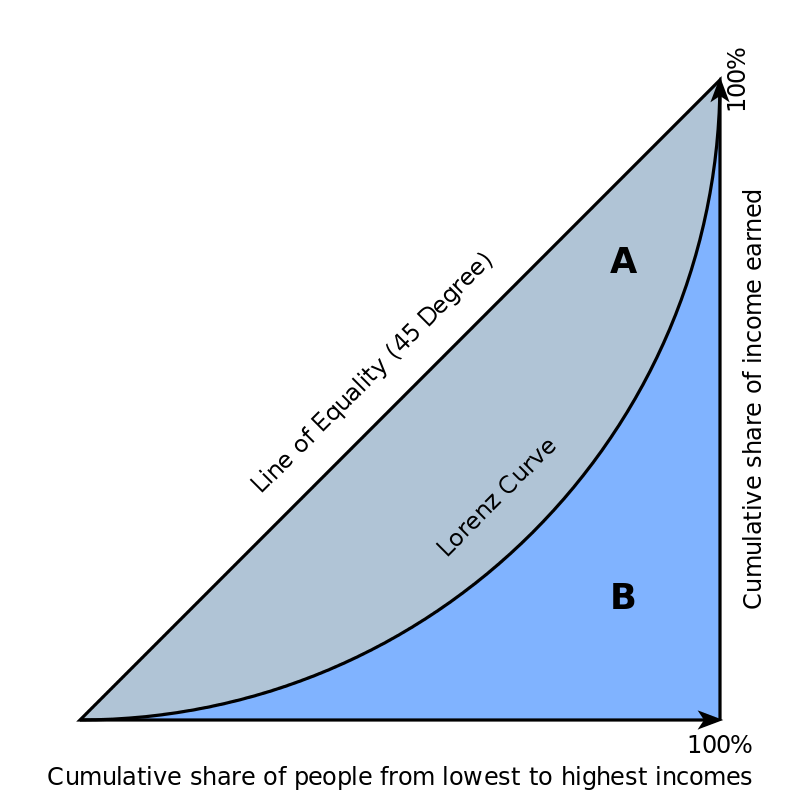

przekątna łącząca lewy-dolny, prawy-górny wierzchołek jest nazywana linią równomiernego rozkładu (koncentracji równomiernej, *line of equality*). **Współczynnik Giniego** to iloraz pola A do sumy pół A+B.

Im większa koncentracji, tym krzywa Lorenza jest bardziej wygięta, a wartość współczynnika Ginego większa (maksymalną wartością jest 1)

*Współczynnik HH*

Innym współczynnikiem koncentracji jest współczynnik Herfindahla-Hirschmana (HH-Index, https://en.wikipedia.org/wiki/Herfindahl%E2%80%93Hirschman_Index):

$$HH = \sum_{i=1}^N x_i^2, \quad\mathrm{gdzie}: \sum_{i=1}^N x_i =100%$$
Maksymalną wartością tego współczynnika jest 10000, wartości większe od 1800 świadczą o znacznej koncentracji.

# Analiza korelacji

## Wykresy

Zależność pomiędzy uzwiązkowieniem (liczonym jako udział płac związkowców w całości płac) a wielkością GDP (na głowę, czyli per capita):

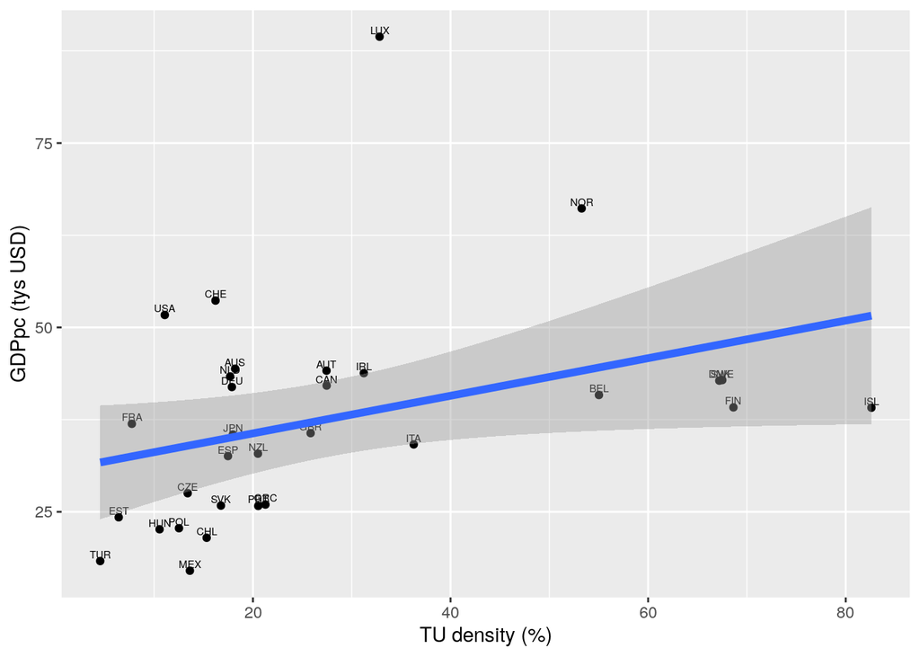

# Analiza szeregów czasowych

### Wykresy

W przypadku szeregów czasowych celem wizualizacji jest: pokazanie poziomu zjawiska, jego dynamiki (spada, rośnie, zmienia się cyklicznie), porównanie poziomów/dynamiki wielu zmiennych.

Do wizualizacji szeregów czasowych należy stosować wykresy punktowe, liniowe lub słupkowe.

**Przykład 1: Zwiedzający Muzeum Zamkowe w Malborku**

Plik `MZM.csv` zawiera liczę zwiedzających Muzeum Zamkowe w Malborku (w latach 2015-2019; dane miesięczne)

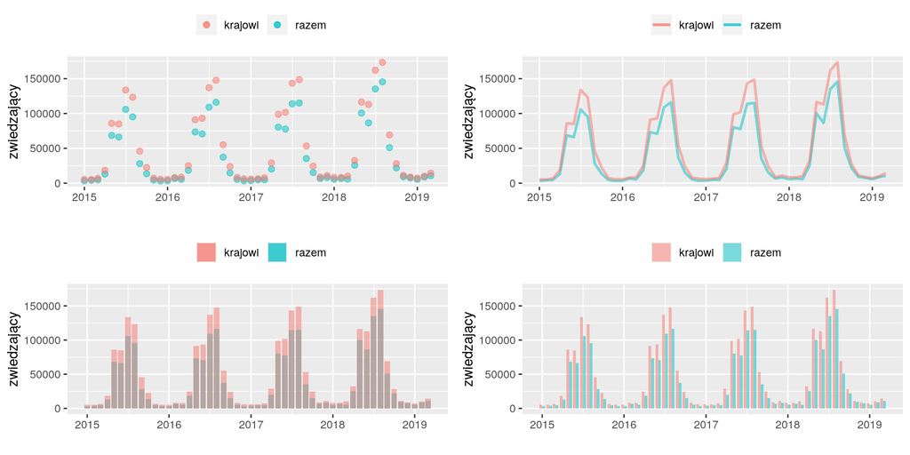

Wykres kropkowy zwykle się nie sprawdza. Jeżeli przebieg zjawiska nie jest uporządkowany albo wykres zawiera kilka zmiennych (w przykładzie dwie zmienne). to wynikiem jest chmura różnokolowych kropek w której trudno się połapać.

Wykres liniowy zwykle daje najlepsze rezultaty.

Wykres słupkowy z półprzeźroczystymi słupkami też zwykle się nie sprawdza (w przykładzie jeden słupek zawsze zachodzi na drugi, co w rezultacie prowadzi do sytuacji, że turkusowego koloru w ogóle nie ma na wykresie)

Wykres słupkowy ze słupkami przylegającymi do siebie (grupowany) jest dobrą alternatywą dla wykresu liniowego.

# Wnioskowanie statystyczne

[…]